# Ptychodera Cisreg Development: Data Load and Normalisation

Alberto Perez-Posada

3/24/2023

## About

In this markdown we will load the mapped RNA-seq counts of Ptychodera and normalise/transform the data, Using edgeR and RUV-Seq, for proper downstream analysis.

## Load libraries

```r
library(DESeq2)
library(tximport)
library(RUVSeq)
library(rhdf5)
library(apeglm)
library(gplots)
library(pheatmap)
library(scales)
```

## Load functions

```r
#from @Rich Scriven https://stackoverflow.com/questions/26045478/source-r-scripts-in-different-folders
sourceFolder <- function(folder, recursive = FALSE, ...)
{
    files <- list.files(folder, pattern = "[.][rR]$",
                        full.names = TRUE, recursive = recursive)
    if (!length(files))
        stop(simpleError(sprintf('No R files in folder "%s"', folder)))
    src <- invisible(lapply(files, source, ...))
    message(sprintf('%s files sourced from folder "%s"', length(src), folder))
}

sourceFolder(
  "code/r_code/r_functions",
  recursive = TRUE
  )

sourceFolder(
  "code/r_code/r_general",
  recursive = TRUE
  )
```

## Data Load

Preliminary DESeq2 design to retrieve the non-normalized count matrix.

```r
samplesdir <-
  "data/RNA/kallisto/abundances/"

sampleTable <-
  read.table(
    "data/RNA/kallisto/abundances/sample_table.tsv",
    header = F
  )[, c(1, 1, 2, 3,4)]

colnames(sampleTable) <-
  c("name", "dir", "condition", "batch0","batch")

sampleTable
```

```
##          name        dir condition batch0 batch
## 1    00_Uf_02   00_Uf_02     00_Uf      2     2
## 2  01_1632_01 01_1632_01   01_1632      1     1
## 3  01_1632_02 01_1632_02   01_1632      2     2
## 4    02_EB_02   02_EB_02     02_EB      2     2
## 5    02_EB_03   02_EB_03     02_EB      3     3
## 6    03_LB_01   03_LB_01     03_LB      1     1
## 7    03_LB_02   03_LB_02     03_LB      2     2
## 8    04_EG_01   04_EG_01     04_EG      1     1
## 9    04_EG_02   04_EG_02     04_EG      2     2
## 10   04_EG_04   04_EG_04     04_EG      4     5
## 11  05_MG1_01  05_MG1_01    05_MG1      1     1
## 12  05_MG1_02  05_MG1_02    05_MG1      2     2
## 13  05_MG1_04  05_MG1_04    05_MG1      4     5
## 14  06_MG2_02  06_MG2_02    06_MG2      2     2
```

[output cut: 17 more lines]

```r
files <-
  setNames(
    object = list.files(
      samplesdir,
      "h5",
      recursive = T,
      full.names = T
      ),
    list.dirs(
      samplesdir,
      full.names = F
      )[-1]
  )

txi.kallisto <-
  tximport(
    files,
    type = "kallisto",
    txOut = TRUE
    )
```

```
## 1 2 3 4 5 6 7 8 9 10 11 12 13 14 15 16 17 18 19 20 21 22 23 24 25 26 27 28 29 30 31
```

```r
dds_Txi <-
  DESeqDataSetFromTximport(
    txi.kallisto,
    colData = sampleTable,
    design = ~ batch + condition
    )
```

```
##   the design formula contains one or more numeric variables with integer values,
##   specifying a model with increasing fold change for higher values.
##   did you mean for this to be a factor? if so, first convert
##   this variable to a factor using the factor() function
## using counts and average transcript lengths from tximport
```

```r
dds_Txi$condition <-
  relevel(dds_Txi$condition, ref = c("00_Uf"))
```

## Normalisation using edgeR and RUV-Seq

### Data preparation from the preliminary DESeq2 data

We will extract the raw counts from this newly-generated DESeq2 object. We will apply a filter to keep only the genes that have more than five counts in at least two columns (in our case, developmental stages)

```r
counts_nonorm <- counts(dds_Txi[,c(1:31)],normalized=F)

allgenes <- rownames(counts_nonorm)

filter <-
  apply(
    counts_nonorm, 1,
    function(x) length(x[x>5])>=2
    )

counts_nonorm_filt <- counts_nonorm[filter,]

condition_x <- as.factor(substr(sampleTable$condition,1,5))
```

We define an edgeR expressionset:

```r
set <- newSeqExpressionSet(as.matrix(counts_nonorm_filt),
                           phenoData = data.frame(condition_x, row.names=colnames(counts_nonorm_filt)))

set
```

```
## SeqExpressionSet (storageMode: lockedEnvironment)
## assayData: 30635 features, 31 samples
##   element names: counts, normalizedCounts, offset
## protocolData: none
## phenoData
##   sampleNames: 00_Uf_02 01_1632_01 ... 15_Ad_11 (31 total)
##   varLabels: condition_x
##   varMetadata: labelDescription
## featureData: none
## experimentData: use 'experimentData(object)'
## Annotation:
```

And the structure of the data in this expressionset:

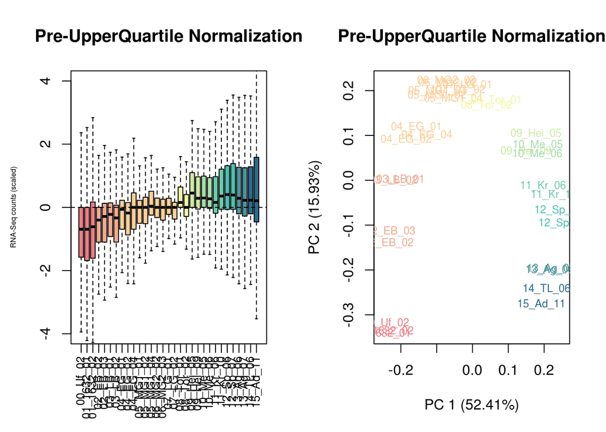

```r
par(mfrow=c(1,2))
plotRLE(
  set,
  outline=FALSE,
  ylim=c(-4, 4),
  col=dev_palette[condition_x],
  cex.lab=0.5,
  main="Pre-UpperQuartile Normalization",
  xaxt="n",
  ylab="RNA-Seq counts (scaled)"
  )

axis(side = 1, at=1:length(colnames(set)), labels = FALSE)
text(x = 1:length(colnames(set)),
     ## Move labels to just below bottom of chart.
     y = par("usr")[3] - 0.45,
     ## Use names from the data list.
     labels = colnames(set),
     ## Change the clipping region.
     xpd = NA,
     ## Rotate the labels by 35 degrees.
     srt = 90,
     ## Adjust the labels to almost 100% right-justified.
     adj = 0.965,
     ## Increase label size.
     cex = 0.8)

plotPCA(
  set,
  col=dev_palette[condition_x],
  cex=0.75,
  main="Pre-UpperQuartile Normalization"
  )
```

As we can see the count distribution varies widely across samples. We will address this doing upper quantile normalisation.

### Upper Quantile Normalisation

```r
set <- betweenLaneNormalization(set, which="upper")
```

And after Upper Quantile Normlisation:

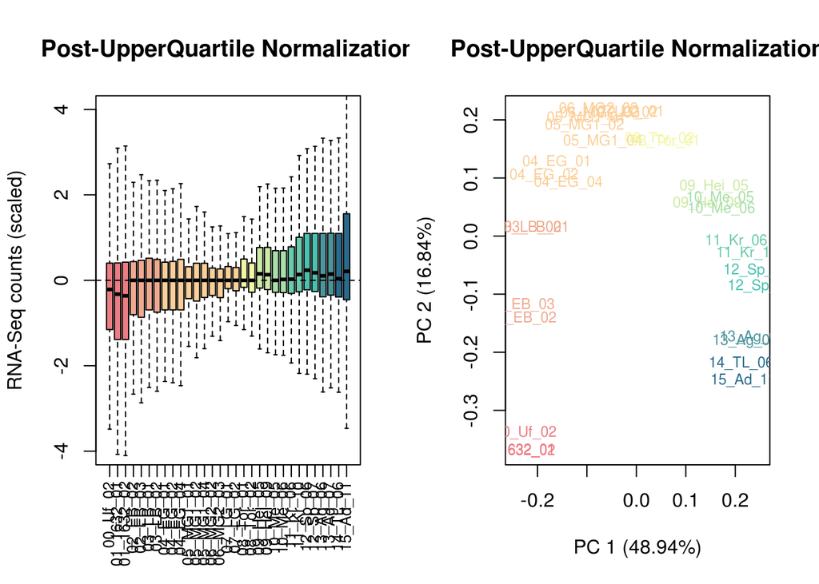

```r
par(mfrow = c(1,2) )

plotRLE(
  set,
  outline=FALSE,
  ylim=c(-4, 4),
  col=dev_palette[condition_x],
  main="Post-UpperQuartile Normalization",
  xaxt="n",
  ylab="RNA-Seq counts (scaled)"
  )

axis(side = 1, at=1:length(colnames(set)), labels = FALSE)

text(x = 1:length(colnames(set)),
     ## Move labels to just below bottom of chart.
     y = par("usr")[3] - 0.45,
     ## Use names from the data list.
     labels = colnames(set),
     ## Change the clipping region.
     xpd = NA,
     ## Rotate the labels by 35 degrees.
     srt = 90,
     ## Adjust the labels to almost 100% right-justified.
     adj = 0.965,
     ## Increase label size.
     cex = 0.8)

plotPCA(
  set,
  col=dev_palette[condition_x],
  cex=0.75,main="Post-UpperQuartile Normalization"
  )
```

Things are looking much better now.

### Remove Unwanted Variation with RUV-Seq

First, edgeR to identify in-silico empirical genes that do not change, using linear modeling.

We will create a design matrix using `model.matrix` to let it know the conditions that are the same (==replicates of the same developmental stages). Then we create a `DGEList` object and calculate normalised factors and estimate dispersion (using `calcNormFactors` and `estimateGLMCommonDisp` and `estimateGLMTagwiseDisp`).

We will fit the data to the design matrix.

```r
design <- model.matrix(~condition_x, data=pData(set))

y <- DGEList(counts=counts(set), group=condition_x)

y <- calcNormFactors(y, method="upperquartile")
y <- estimateGLMCommonDisp(y, design)
y <- estimateGLMTagwiseDisp(y, design)

fit <- glmFit(y, design)
lrt <- glmLRT(fit, coef=2)
top <- topTags(lrt, n=nrow(set))$table

top[1:10,]
```

```
##                    logFC   logCPM       LR
## TCONS_00005030 -4.003037 8.732054 220.3022
## TCONS_00018461 -4.033754 8.337291 207.8846
## TCONS_00013618 -3.508205 8.833437 201.9939
## TCONS_00012905 -3.952644 9.192574 198.0307
## TCONS_00009844 -3.232572 8.365794 187.7503
## TCONS_00056106 -4.091593 8.854621 178.2763
## TCONS_00046675 -2.633283 6.994405 174.0326
## TCONS_00002772 -4.288662 4.346870 168.8162
## TCONS_00043031 -2.664981 9.628135 162.2972
## TCONS_00014432 -3.875981 4.710584 159.8199
##                                                                    PValue
## TCONS_00005030 0.00000000000000000000000000000000000000000000000007770817
## TCONS_00018461 0.00000000000000000000000000000000000000000000003975498921
## TCONS_00013618 0.00000000000000000000000000000000000000000000076686667865
## TCONS_00012905 0.00000000000000000000000000000000000000000000561807798746
## TCONS_00009844 0.00000000000000000000000000000000000000000098492883245382
## TCONS_00056106 0.00000000000000000000000000000000000000011529030300268666
## TCONS_00046675 0.00000000000000000000000000000000000000097377101870109734
## TCONS_00002772 0.00000000000000000000000000000000000001341904688235070806
## TCONS_00043031 0.00000000000000000000000000000000000035624765628238686529
## TCONS_00014432 0.00000000000000000000000000000000000123878577002909777071
##                                                                 FDR
## TCONS_00005030 0.00000000000000000000000000000000000000000000238059
## TCONS_00018461 0.00000000000000000000000000000000000000000060894705
## TCONS_00013618 0.00000000000000000000000000000000000000000783098690
## TCONS_00012905 0.00000000000000000000000000000000000000004302745479
## TCONS_00009844 0.00000000000000000000000000000000000000603465895644
## TCONS_00056106 0.00000000000000000000000000000000000058865307208122
## TCONS_00046675 0.00000000000000000000000000000000000426163930827259
## TCONS_00002772 0.00000000000000000000000000000000005138656265510175
## TCONS_00043031 0.00000000000000000000000000000000121262743891232452
## TCONS_00014432 0.00000000000000000000000000000000379502020648414076
```

From this, we can identify those genes who do NOT change across conditions.

```r
empirical <-
  rownames(set)[
    which(
      !(rownames(set) %in% rownames(top)[1:10000])
      )
    ]

empirical[1:10]
```

```
##  [1] "TCONS_00038693" "TCONS_00038695" "TCONS_00038635" "TCONS_00038698"
##  [5] "TCONS_00038637" "TCONS_00038701" "TCONS_00038702" "TCONS_00038704"
##  [9] "TCONS_00038706" "TCONS_00038712"
```

We can pass this down to RUV-Seq as in-silico determined invariant genes. Based on this, RUV-Seq will transform the data to account for the unwanted variation as estimated by changes in the in-silico invariant genes.

```r
set2 <- RUVg(set, empirical, k=1)

pData(set2)
```

```
##            condition_x         W_1
## 00_Uf_02         00_Uf -0.23321516
## 01_1632_01       01_16 -0.23381486
## 01_1632_02       01_16 -0.23448824
## 02_EB_02         02_EB -0.22437394
## 02_EB_03         02_EB -0.22816467
## 03_LB_01         03_LB -0.19776960
## 03_LB_02         03_LB -0.21378889
## 04_EG_01         04_EG -0.16029604
## 04_EG_02         04_EG -0.18762142
## 04_EG_04         04_EG -0.13437258
## 05_MG1_01        05_MG -0.10556470
## 05_MG1_02        05_MG -0.10781771
## 05_MG1_04        05_MG -0.07017975
## 06_MG2_02        06_MG -0.08202726
## 06_MG2_03        06_MG -0.08528907
## 07_LG_01         07_LG -0.01944652
## 07_LG_02         07_LG -0.03622733
## 08_Tor_01        08_To  0.05362820
## 08_Tor_02        08_To  0.03722196
## 09_Hei_05        09_He  0.15349817
## 09_Hei_09        09_He  0.13854167
## 10_Me_05         10_Me  0.16752496
## 10_Me_06         10_Me  0.17111297
## 11_Kr_06         11_Kr  0.20506812
## 11_Kr_10         11_Kr  0.22697746
## 12_Sp_06         12_Sp  0.24700601
## 12_Sp_07         12_Sp  0.25737845
## 13_Ag_06         13_Ag  0.22040066
## 13_Ag_07         13_Ag  0.23832633
## 14_TL_06         14_TL  0.21680116
## 15_Ad_11         15_Ad  0.22097161
```

A look at the normalised counts after removing unwanted variation.

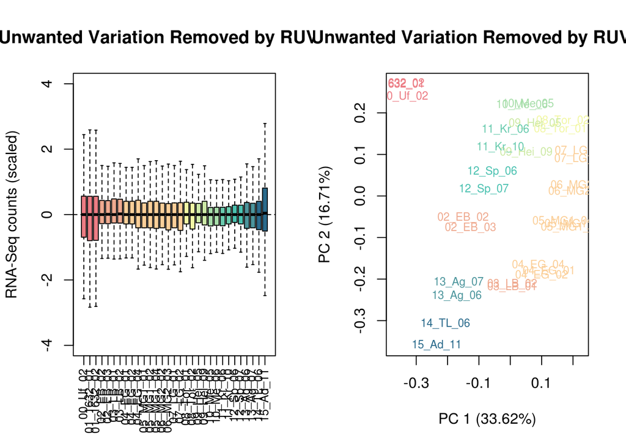

```r
par(mfrow = c(1,2))
plotRLE(
  set2,
  outline=FALSE,
  ylim=c(-4, 4),
  col=dev_palette[condition_x],
  main="Unwanted Variation Removed by RUVSeq",
  xaxt="n",
  ylab="RNA-Seq counts (scaled)"
  )

axis(side = 1, at=1:length(colnames(set)), labels = FALSE)

text(x = 1:length(colnames(set2)),
     ## Move labels to just below bottom of chart.
     y = par("usr")[3] - 0.45,
     ## Use names from the data list.
     labels = colnames(set2),
     ## Change the clipping region.
     xpd = NA,
     ## Rotate the labels by 35 degrees.
     srt = 90,
     ## Adjust the labels to almost 100% right-justified.
     adj = 0.965,
     ## Increase label size.
     cex = 0.8)

plotPCA(
  set2,
  col=dev_palette[condition_x],
  cex=0.75,
  main="Unwanted Variation Removed by RUVSeq"
  )
```

We finally generate a plain gene expression table with counts:

```r
pfla_rna_counts <-
  counts(set2)
```

We will save all the pertinent data in a rda for further analysis using DESeq2:

```r
save(
  # final counts
  set2,
  pfla_rna_counts,
  # condition
  condition_x,
  # sample table
  sampleTable,
  # list of all genes
  allgenes,
  file = "outputs/rda/normalised_counts.rda"
)
```